# 8. 股票收益率方向预测

## 一、实验简介

本实验围绕 **股票（或指数）未来收益率方向预测** 场景展开，使用 Random Forest、XGBoost 和 LSTM 三种模型，基于公开行情数据构建技术指标特征，通过 **滚动窗口（Rolling Window）** 方式进行样本外预测，并系统比较树模型与神经网络的表现。

**为什么预测"方向"而非"价格"？**

许多初学者习惯用神经网络拟合收盘价序列，然后声称"预测误差很小"。然而，这种做法存在严重问题：

| 方法 | 典型做法 | 问题 |
| --- | --- | --- |
| **收盘价拟合** | 用前 N 天收盘价预测第 N+1 天收盘价 | 模型学到的只是"明天的价格≈今天的价格"，本质上是滞后复制，毫无实际交易价值 |
| **收益率方向预测** | 预测未来 K 日收益率为正还是负 | 直接对应交易决策（做多/做空/观望），评估指标具有经济含义 |

下图直观说明了为什么收盘价拟合的"高精度"具有欺骗性：

```
真实价格:  100 → 102 → 101 → 103 → 105
滞后预测:       100 → 102 → 101 → 103      ← 看起来"很准"，但永远慢一拍
方向预测:        ↑     ↓     ↑     ↑       ← 直接给出交易信号
```

**为什么同时使用树模型和神经网络？**

| 模型 | 优势 | 劣势 |
| --- | --- | --- |
| **Random Forest** | 稳健、不易过拟合、特征重要性可解读 | 难以捕捉时序依赖关系 |
| **XGBoost** | 预测性能强、支持正则化 | 同上，需手工构造滞后特征 |
| **LSTM** | 天然处理序列依赖、可建模长期记忆 | 易过拟合、训练慢、超参敏感 |

本实验使用 **Yahoo Finance** 公开行情接口获取数据，构建常用技术指标作为特征，采用滚动窗口进行时间序列交叉验证。

## 二、实验目标

- 理解为什么股票预测应关注 **收益率方向** 而非收盘价拟合，以及"Look-Ahead Bias（前视偏差）"的概念。
- 掌握常用技术指标（移动平均、RSI、MACD、布林带等）的构造方法及其金融含义。
- 理解 **滚动窗口预测（Walk-Forward Validation）** 为什么是时间序列建模中唯一合理的评估方式。
- 分别构建 Random Forest、XGBoost 和 LSTM 模型，比较树模型与神经网络在样本外的方向预测能力。
- 使用方向准确率（Directional Accuracy）、分类指标（Precision / Recall / F1）和 AUC-ROC 评估模型。

## 三、实验要求

- 使用 `yfinance` 获取至少 5 年的日频行情数据（如沪深 300 ETF 或标普 500 指数）。
- 构建不少于 8 个技术指标特征。
- 使用滚动窗口方式进行训练与预测，**严禁使用未来数据**。
- 分别训练 Random Forest、XGBoost 和 LSTM 模型。
- 输出模型对比图、样本外评估结果和收益率方向预测报告。

## 四、思考提示

1. 为什么不能像普通分类任务那样直接用 `train_test_split` 随机划分训练/测试集？
2. 技术指标本质上都是对历史价格/成交量的变换，它们真的包含"预测信息"还是只是噪声？
3. LSTM 在金融时间序列上是否真的比树模型更优？文献中怎么说？
4. 如果模型的方向准确率是 53%，它在实际交易中能盈利吗？需要考虑什么额外因素？
5. 样本外表现远不如样本内表现时，最可能的原因是什么？

## 1. 环境准备

```python
from __future__ import annotations

import warnings

import matplotlib.pyplot as plt
import matplotlib.patches as mpatches
import numpy as np
import pandas as pd
import seaborn as sns
from matplotlib import font_manager

# 行情数据
# Ref: https://github.com/ranaroussi/yfinance
import yfinance as yf

# 树模型
from sklearn.ensemble import RandomForestClassifier
# Ref: https://xgboost.readthedocs.io/
import xgboost as xgb

# 神经网络 (LSTM) — PyTorch
# Ref: https://pytorch.org/docs/stable/generated/torch.nn.LSTM.html
import torch
import torch.nn as nn
from torch.utils.data import TensorDataset, DataLoader

# 评估
from sklearn.metrics import (
    accuracy_score, precision_score, recall_score, f1_score,
    roc_auc_score, roc_curve, confusion_matrix, classification_report,
)
from sklearn.preprocessing import StandardScaler

warnings.filterwarnings("ignore")

# 自动选择设备
device = torch.device("cuda" if torch.cuda.is_available() else "cpu")
print(f"PyTorch 版本：{torch.__version__}，使用设备：{device}")
```

```
PyTorch 版本：2.11.0+cu130，使用设备：cuda
```

配置中文字体，确保图表标签正确显示：

```python
def configure_plot_fonts() -> None:
    """配置 matplotlib 中文字体，避免 seaborn 主题覆盖字体设置。"""
    sns.set_theme(style="whitegrid")
    font_candidates = [
        "Microsoft YaHei", "SimHei", "Noto Sans CJK SC",
        "PingFang SC", "WenQuanYi Zen Hei",
    ]
    available_fonts = {f.name for f in font_manager.fontManager.ttflist}
    selected_font = next(
        (name for name in font_candidates if name in available_fonts), None
    )
    if selected_font is None:
        warnings.warn(
            "未检测到常见中文字体，图表中文可能显示为方块。"
            "建议安装 'Microsoft YaHei' 或 'Noto Sans CJK SC'。",
            UserWarning,
        )
        plt.rcParams["font.sans-serif"] = ["DejaVu Sans"]
    else:
        plt.rcParams["font.sans-serif"] = [selected_font, "DejaVu Sans"]
    plt.rcParams["axes.unicode_minus"] = False


configure_plot_fonts()
```

## 2. 数据获取与探索

### 2.1 使用 Yahoo Finance 获取行情数据

我们使用 `yfinance` 库获取标普 500 指数（`^GSPC`）的日频行情数据。选择标普 500 是因为它流动性好、数据质量高、覆盖时间长，便于构建和验证模型。

> 如果希望预测 A 股市场，可将 ticker 替换为沪深 300 ETF（`510300.SS`）或上证指数（`000001.SS`）。

```python
# Ref: https://github.com/ranaroussi/yfinance
ticker = "^GSPC"  # 标普 500 指数
raw = yf.download(ticker, start="2008-01-01", end="2024-12-31", auto_adjust=True)
raw = raw.droplevel("Ticker", axis=1) if isinstance(raw.columns, pd.MultiIndex) else raw

print(f"数据区间：{raw.index.min().date()} — {raw.index.max().date()}")
print(f"总交易日数：{len(raw)}")
display(raw.tail())
```

```
[*********************100%***********************]  1 of 1 completed
```

```
数据区间：2008-01-02 — 2024-12-30
总交易日数：4278
```

| Price Date | Close | High | Low | Open | Volume |
| --- | --- | --- | --- | --- | --- |
| 2024-12-23 | 5974.069824 | 5978.250000 | 5902.569824 | 5940.250000 | 3593280000 |
| 2024-12-24 | 6040.040039 | 6040.100098 | 5981.439941 | 5984.629883 | 1757720000 |
| 2024-12-26 | 6037.589844 | 6049.750000 | 6007.370117 | 6024.970215 | 2904530000 |
| 2024-12-27 | 5970.839844 | 6006.169922 | 5932.950195 | 6006.169922 | 3159610000 |
| 2024-12-30 | 5906.939941 | 5940.790039 | 5869.160156 | 5920.669922 | 3433250000 |

### 2.2 价格与成交量概览

先对原始行情进行可视化，直观了解数据的时间跨度和市场走势：

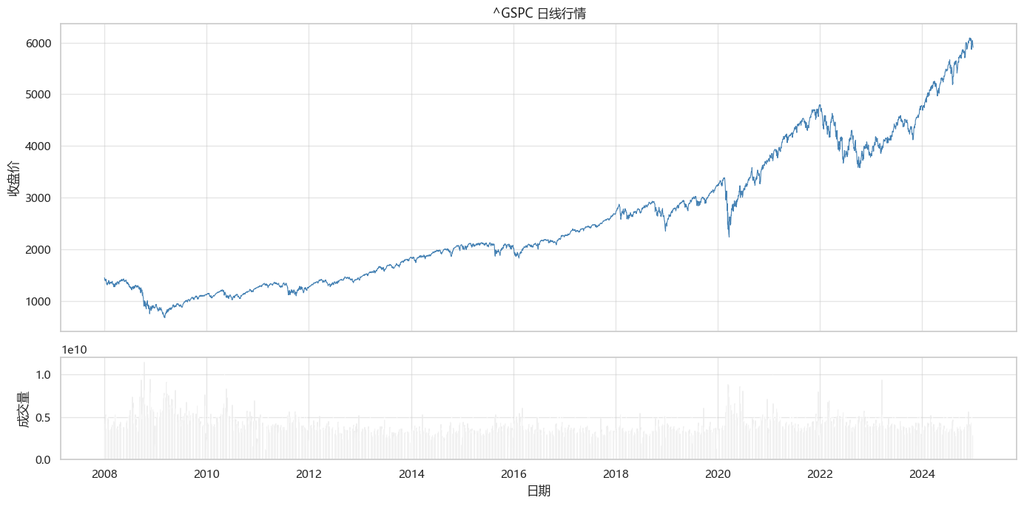

```python
fig, axes = plt.subplots(2, 1, figsize=(14, 7), sharex=True,
                         gridspec_kw={"height_ratios": [3, 1]})

axes[0].plot(raw.index, raw["Close"], color="steelblue", linewidth=0.8)
axes[0].set_ylabel("收盘价")
axes[0].set_title(f"{ticker} 日线行情")

axes[1].bar(raw.index, raw["Volume"], color="gray", alpha=0.6, width=1)
axes[1].set_ylabel("成交量")
axes[1].set_xlabel("日期")

plt.tight_layout()
plt.show()
```

### 2.3 计算收益率与定义预测目标

我们预测的目标是 **未来 1 日对数收益率的方向**：

$$r_t = \ln\!\left(\frac{P_t}{P_{t-1}}\right)$$

$$y_t = \begin{cases} 1, & \text{若 } r_{t+1} > 0 \quad \text{(上涨)} \\ 0, & \text{若 } r_{t+1} \le 0 \quad \text{(下跌或持平)} \end{cases}$$

**为什么用对数收益率？** 对数收益率具有可加性（多日收益率可直接相加），且分布更接近正态，这在统计建模中非常有利。

```python
df = raw[["Open", "High", "Low", "Close", "Volume"]].copy()

# 对数收益率
df["log_return"] = np.log(df["Close"] / df["Close"].shift(1))

# 预测目标：未来 1 日收益率方向
# 注意：使用 shift(-1)，即用"明天的收益率"作为今天的标签
df["target"] = (df["log_return"].shift(-1) > 0).astype(int)

print(f"日收益率统计：")
display(df["log_return"].describe())
print(f"\n目标变量分布（0=下跌/持平, 1=上涨）：")
print(df["target"].value_counts())
print(f"上涨比例：{df['target'].mean():.4f}")
```

```
日收益率统计：
```

```
count    4277.000000
mean        0.000329
std         0.012711
min        -0.127652
25%        -0.004165
50%         0.000702
75%         0.005970
max         0.109572
Name: log_return, dtype: float64
```

```
目标变量分布（0=下跌/持平, 1=上涨）：
target
1    2322
0    1956
Name: count, dtype: int64
上涨比例：0.5428
```

> **重要提醒**：`shift(-1)` 代表"明天的信息"。在构建特征时，**所有特征都只能使用当天及之前的数据**，绝不能使用未来数据。这就是所谓的 **前视偏差（Look-Ahead Bias）**——一旦引入，模型的样本外表现将严重失真。

## 3. 特征工程：构建技术指标

技术指标是量化交易中最常用的特征来源。它们将原始的价格与成交量信息变换为更有表现力的信号。下面我们构建 8 类常用技术指标。

### 3.1 移动平均线（Moving Average）

移动平均线是最基础的趋势指标。短期均线在长期均线之上，通常被视为上升趋势信号（"金叉"）。

```python
# 简单移动平均线（SMA）
for window in [5, 10, 20, 60]:
    df[f"SMA_{window}"] = df["Close"].rolling(window).mean()

# 收盘价相对于均线的位置（标准化）
for window in [5, 10, 20, 60]:
    df[f"Close_SMA{window}_ratio"] = df["Close"] / df[f"SMA_{window}"]
```

### 3.2 指数移动平均线（EMA）

EMA 对近期价格赋予更高权重，响应更灵敏：

```python
for span in [12, 26]:
    df[f"EMA_{span}"] = df["Close"].ewm(span=span, adjust=False).mean()
```

### 3.3 MACD（Moving Average Convergence Divergence）

MACD 由快线（EMA12 − EMA26）、信号线（MACD 的 9 日 EMA）和柱状图（两者之差）组成，是最常用的趋势/动量指标之一。

```python
df["MACD"] = df["EMA_12"] - df["EMA_26"]
df["MACD_signal"] = df["MACD"].ewm(span=9, adjust=False).mean()
df["MACD_hist"] = df["MACD"] - df["MACD_signal"]
```

### 3.4 RSI（Relative Strength Index）

RSI 衡量一段时间内上涨幅度与总波动幅度的比值，取值范围 [0, 100]。RSI > 70 通常被视为超买，RSI < 30 被视为超卖。

```python
def compute_rsi(series: pd.Series, period: int = 14) -> pd.Series:
    """计算 RSI 指标。"""
    delta = series.diff()
    gain = delta.clip(lower=0)
    loss = (-delta).clip(lower=0)
    avg_gain = gain.rolling(period).mean()
    avg_loss = loss.rolling(period).mean()
    rs = avg_gain / avg_loss
    return 100 - (100 / (1 + rs))


df["RSI_14"] = compute_rsi(df["Close"], 14)
```

### 3.5 布林带（Bollinger Bands）

布林带由中轨（20 日 SMA）和上下轨（中轨 ± 2 倍标准差）组成。价格触及上轨可能过热，触及下轨可能超卖。我们使用 **%B 指标**（价格在布林带中的相对位置）作为特征。

```python
bb_window = 20
df["BB_mid"] = df["Close"].rolling(bb_window).mean()
bb_std = df["Close"].rolling(bb_window).std()
df["BB_upper"] = df["BB_mid"] + 2 * bb_std
df["BB_lower"] = df["BB_mid"] - 2 * bb_std

# %B = (Close - Lower) / (Upper - Lower)
df["BB_pctB"] = (df["Close"] - df["BB_lower"]) / (df["BB_upper"] - df["BB_lower"])
```

### 3.6 波动率特征

历史波动率是风险的直接度量。高波动率期间，方向预测往往更困难。

```python
for window in [5, 10, 20]:
    df[f"volatility_{window}"] = df["log_return"].rolling(window).std()
```

### 3.7 成交量特征

成交量反映市场参与者的活跃程度。"放量上涨"和"缩量下跌"具有不同的技术含义。

```python
# 成交量变化率
df["volume_change"] = df["Volume"].pct_change()

# 成交量相对于 20 日均量的比值
df["volume_SMA20_ratio"] = df["Volume"] / df["Volume"].rolling(20).mean()
```

### 3.8 滞后收益率特征

过去几日的收益率本身也包含信息（动量效应或均值回复效应）：

```python
for lag in [1, 2, 3, 5, 10]:
    df[f"return_lag_{lag}"] = df["log_return"].shift(lag)
```

### 3.9 清理数据并确定最终特征集

特征构建过程中引入了大量 NaN（由 rolling 窗口和 shift 产生）。我们需要删除这些行，并排除原始价格列和目标变量，形成最终的特征矩阵。

```python
feature_cols = [
    # 价格-均线比率
    "Close_SMA5_ratio", "Close_SMA10_ratio", "Close_SMA20_ratio", "Close_SMA60_ratio",
    # MACD 系列
    "MACD", "MACD_signal", "MACD_hist",
    # RSI
    "RSI_14",
    # 布林带
    "BB_pctB",
    # 波动率
    "volatility_5", "volatility_10", "volatility_20",
    # 成交量
    "volume_change", "volume_SMA20_ratio",
    # 滞后收益率
    "return_lag_1", "return_lag_2", "return_lag_3", "return_lag_5", "return_lag_10",
]

df_model = df[feature_cols + ["target"]].copy()

df_model.replace([np.inf, -np.inf], np.nan, inplace=True)
df_model.dropna(inplace=True)

print(f"最终建模数据集维度：{df_model.shape}")
print(f"时间区间：{df_model.index.min().date()} — {df_model.index.max().date()}")
print(f"特征数量：{len(feature_cols)}")
print(f"\n特征列表：")
for i, col in enumerate(feature_cols, 1):
    print(f"  {i:2d}. {col}")
```

```
最终建模数据集维度：(4218, 20)
时间区间：2008-03-28 — 2024-12-30
特征数量：19

特征列表：
   1. Close_SMA5_ratio
   2. Close_SMA10_ratio
   3. Close_SMA20_ratio
   4. Close_SMA60_ratio
   5. MACD
   6. MACD_signal
   7. MACD_hist
   8. RSI_14
   9. BB_pctB
  10. volatility_5
  11. volatility_10
  12. volatility_20
  13. volume_change
  14. volume_SMA20_ratio
  15. return_lag_1
  16. return_lag_2
  17. return_lag_3
  18. return_lag_5
  19. return_lag_10
```

### 3.10 特征相关性检查

检查特征之间的相关性，避免严重的多重共线性：

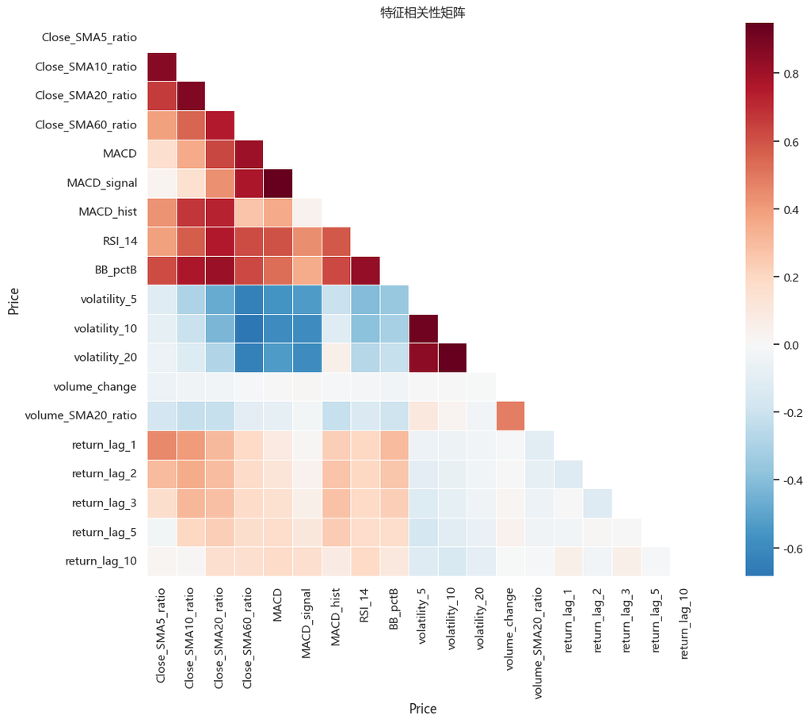

```
相关系数绝对值 > 0.8 的特征对：
  Close_SMA5_ratio — Close_SMA10_ratio: 0.861
  Close_SMA10_ratio — Close_SMA20_ratio: 0.875
  Close_SMA20_ratio — BB_pctB: 0.815
  Close_SMA60_ratio — MACD: 0.811
  MACD — MACD_signal: 0.948
  RSI_14 — BB_pctB: 0.832
  volatility_5 — volatility_10: 0.918
  volatility_5 — volatility_20: 0.841
  volatility_10 — volatility_20: 0.938
```

```python
plt.figure(figsize=(14, 10))
corr_matrix = df_model[feature_cols].corr()
mask = np.triu(np.ones_like(corr_matrix, dtype=bool))
sns.heatmap(corr_matrix, mask=mask, cmap="RdBu_r", center=0,
            annot=False, square=True, linewidths=0.5)
plt.title("特征相关性矩阵")
plt.tight_layout()
plt.grid(None)
plt.show()

# 找出高相关特征对
high_corr_pairs = []
for i in range(len(corr_matrix)):
    for j in range(i + 1, len(corr_matrix)):
        if abs(corr_matrix.iloc[i, j]) > 0.8:
            high_corr_pairs.append(
                (corr_matrix.index[i], corr_matrix.columns[j],
                 round(corr_matrix.iloc[i, j], 3))
            )

if high_corr_pairs:
    print("相关系数绝对值 > 0.8 的特征对：")
    for f1, f2, c in high_corr_pairs:
        print(f"  {f1} — {f2}: {c}")
else:
    print("不存在相关系数绝对值 > 0.8 的特征对。")
```

> **注意**：高相关性不一定要求删除特征——树模型对多重共线性不敏感。但对于 Logistic 回归或需要解读系数的场景，应当处理。

## 4. 核心概念

### 4.1 为什么不能随机划分训练/测试集？

在普通的分类任务中，我们使用 `train_test_split` 随机划分数据。但时间序列数据具有**时间依赖性**：

```
❌ 随机划分：
  训练集: 2010-03-15, 2015-07-22, 2012-01-08, 2018-11-30, ...
  测试集: 2013-05-10, 2016-02-14, 2011-09-03, ...
  → 训练集中包含了测试集时间点之后的数据，构成"未来信息泄露"

✅ 滚动窗口（Walk-Forward）：
  第 1 轮: 训练 [2010-01 ~ 2014-12] → 预测 [2015-01 ~ 2015-06]
  第 2 轮: 训练 [2010-01 ~ 2015-06] → 预测 [2015-07 ~ 2015-12]
  第 3 轮: 训练 [2010-01 ~ 2015-12] → 预测 [2016-01 ~ 2016-06]
  ...
  → 始终用"过去"预测"未来"，无信息泄露
```

### 4.2 滚动窗口预测（Walk-Forward Validation）

滚动窗口的核心思想是模拟真实交易场景：在每个时间点，只能使用截至当前的历史数据训练模型，然后对下一段未来数据进行预测。

```
|<---------- 训练窗口 ---------->|<-- 预测窗口 -->|
|================================|================|
                                 ↑
                           模型训练截止点
```

- **训练窗口**：从数据起始点到当前截止点。
- **预测窗口**：截止点之后的一段时间（如 6 个月）。
- **滚动**：每次预测窗口结束后，将截止点向前推移，加入新数据重新训练。

### 4.3 LSTM 与时间序列

LSTM（Long Short-Term Memory）是一种特殊的循环神经网络（RNN），通过**门控机制**（遗忘门、输入门、输出门）控制信息的保留与遗忘，擅长处理长期依赖关系。

在金融时间序列场景中，LSTM 的输入是一个 3D 张量：`(样本数, 时间步长, 特征数)`，其中"时间步长"表示用过去多少天的特征来预测未来方向。

```
输入形状: (batch_size, lookback_days, n_features)
         例如: (64, 20, 19) → 64 个样本，每个用过去 20 天的 19 个特征
```

## 5. 滚动窗口框架搭建

### 5.1 定义滚动窗口参数

```python
# 滚动窗口参数
TRAIN_START = "2010-01-01"  # 最早可用的训练数据
PREDICT_START = "2018-01-01"  # 开始做样本外预测的时间点
STEP_MONTHS = 6               # 每个预测窗口的长度（月）
LOOKBACK = 20                  # LSTM 回看天数

print(f"训练数据起始：{TRAIN_START}")
print(f"样本外预测起始：{PREDICT_START}")
print(f"预测窗口步长：{STEP_MONTHS} 个月")
print(f"LSTM 回看天数：{LOOKBACK}")
```

```
训练数据起始：2010-01-01
样本外预测起始：2018-01-01
预测窗口步长：6 个月
LSTM 回看天数：20
```

### 5.2 生成滚动窗口的时间切分点

```python
predict_start_ts = pd.Timestamp(PREDICT_START)
data_end_ts = df_model.index.max()

# 生成每个预测窗口的起止日期
fold_dates = []
current = predict_start_ts
while current < data_end_ts:
    next_point = current + pd.DateOffset(months=STEP_MONTHS)
    if next_point > data_end_ts:
        next_point = data_end_ts
    fold_dates.append((current, next_point))
    current = next_point

print(f"共 {len(fold_dates)} 个预测窗口：")
for i, (start, end) in enumerate(fold_dates):
    print(f"  窗口 {i + 1}: {start.date()} — {end.date()}")
```

```
共 14 个预测窗口：
  窗口 1: 2018-01-01 — 2018-07-01
  窗口 2: 2018-07-01 — 2019-01-01
  窗口 3: 2019-01-01 — 2019-07-01
  窗口 4: 2019-07-01 — 2020-01-01
  窗口 5: 2020-01-01 — 2020-07-01
  窗口 6: 2020-07-01 — 2021-01-01
  窗口 7: 2021-01-01 — 2021-07-01
  窗口 8: 2021-07-01 — 2022-01-01
  窗口 9: 2022-01-01 — 2022-07-01
  窗口 10: 2022-07-01 — 2023-01-01
  窗口 11: 2023-01-01 — 2023-07-01
  窗口 12: 2023-07-01 — 2024-01-01
  窗口 13: 2024-01-01 — 2024-07-01
  窗口 14: 2024-07-01 — 2024-12-30
```

## 6. 训练与滚动预测

### 6.1 LSTM 数据准备工具

LSTM 需要将二维特征矩阵转为三维序列。以下函数将连续 `lookback` 天的特征打包为一个样本：

```python
def create_lstm_sequences(
    X: np.ndarray, y: np.ndarray, lookback: int
) -> tuple[np.ndarray, np.ndarray]:
    """
    将二维特征矩阵转为 LSTM 所需的三维序列。

    参数:
        X: (n_samples, n_features)
        y: (n_samples,)
        lookback: 回看天数

    返回:
        X_seq: (n_samples - lookback, lookback, n_features)
        y_seq: (n_samples - lookback,)
    """
    X_seq, y_seq = [], []
    for i in range(lookback, len(X)):
        X_seq.append(X[i - lookback : i])
        y_seq.append(y[i])
    return np.array(X_seq), np.array(y_seq)
```

### 6.2 构建 LSTM 模型函数

每个滚动窗口都需要重新构建和训练 LSTM 模型（避免信息泄露）。我们将模型构建封装为函数：

```python
class LSTMClassifier(nn.Module):
    """两层 LSTM + 全连接层，输出二分类概率。"""

    def __init__(self, n_features: int, hidden_size: int = 64, num_layers: int = 2,
                 dropout: float = 0.3):
        super().__init__()
        # Ref: https://pytorch.org/docs/stable/generated/torch.nn.LSTM.html
        self.lstm = nn.LSTM(
            input_size=n_features,
            hidden_size=hidden_size,
            num_layers=num_layers,
            batch_first=True,       # 输入形状 (batch, seq_len, features)
            dropout=dropout,        # 层间 dropout（仅 num_layers > 1 时生效）
        )
        self.fc = nn.Linear(hidden_size, 1)

    def forward(self, x: torch.Tensor) -> torch.Tensor:
        # x: (batch, lookback, n_features)
        lstm_out, _ = self.lstm(x)          # (batch, lookback, hidden_size)
        last_hidden = lstm_out[:, -1, :]    # 取最后一个时间步
        logit = self.fc(last_hidden)        # (batch, 1)
        return logit.squeeze(-1)            # (batch,)


def train_lstm(
    X_train_seq: np.ndarray,
    y_train_seq: np.ndarray,
    n_features: int,
    epochs: int = 30,
    batch_size: int = 64,
    patience: int = 5,
    lr: float = 1e-3,
) -> LSTMClassifier:
    """训练 LSTM 模型，支持 early stopping。"""
    # 划出 10% 作为验证集
    val_size = max(1, int(len(X_train_seq) * 0.1))
    X_val_t = torch.tensor(X_train_seq[-val_size:], dtype=torch.float32).to(device)
    y_val_t = torch.tensor(y_train_seq[-val_size:], dtype=torch.float32).to(device)
    X_tr_t = torch.tensor(X_train_seq[:-val_size], dtype=torch.float32).to(device)
    y_tr_t = torch.tensor(y_train_seq[:-val_size], dtype=torch.float32).to(device)

    train_loader = DataLoader(
        TensorDataset(X_tr_t, y_tr_t), batch_size=batch_size, shuffle=True,
    )

    model = LSTMClassifier(n_features).to(device)
    # Ref: https://pytorch.org/docs/stable/generated/torch.nn.BCEWithLogitsLoss.html
    criterion = nn.BCEWithLogitsLoss()
    optimizer = torch.optim.Adam(model.parameters(), lr=lr)

    best_val_loss = float("inf")
    best_state = None
    wait = 0

    for epoch in range(epochs):
        # --- 训练 ---
        model.train()
        for X_batch, y_batch in train_loader:
            optimizer.zero_grad()
            logits = model(X_batch)
            loss = criterion(logits, y_batch)
            loss.backward()
            optimizer.step()

        # --- 验证 ---
        model.eval()
        with torch.no_grad():
            val_logits = model(X_val_t)
            val_loss = criterion(val_logits, y_val_t).item()

        # --- Early Stopping ---
        if val_loss < best_val_loss:
            best_val_loss = val_loss
            best_state = model.state_dict().copy()
            wait = 0
        else:
            wait += 1
            if wait >= patience:
                break

    # 恢复最优权重
    if best_state is not None:
        model.load_state_dict(best_state)
    model.eval()
    return model


def predict_lstm(model: LSTMClassifier, X_seq: np.ndarray) -> np.ndarray:
    """用训练好的 LSTM 输出预测概率。"""
    model.eval()
    X_t = torch.tensor(X_seq, dtype=torch.float32).to(device)
    with torch.no_grad():
        logits = model(X_t)
        probs = torch.sigmoid(logits).cpu().numpy()
    return probs
```

### 6.3 执行滚动预测

下面是本实验的核心循环。对每个预测窗口，我们：

1. 用窗口起始日之前的所有数据作为训练集。
2. 用窗口内的数据作为测试集。
3. 分别训练三个模型并收集预测结果。

```python
# 存储所有预测结果
all_results = {
    "date": [],
    "y_true": [],
    "rf_prob": [],
    "xgb_prob": [],
    "lstm_prob": [],
}

n_features = len(feature_cols)

for fold_idx, (pred_start, pred_end) in enumerate(fold_dates):
    print(f"\n{'='*60}")
    print(f"窗口 {fold_idx + 1}/{len(fold_dates)}: "
          f"预测区间 {pred_start.date()} — {pred_end.date()}")
    print(f"{'='*60}")

    # --- 划分训练/测试集 ---
    train_data = df_model.loc[:pred_start].iloc[:-1]  # 严格在预测起始日之前
    test_data = df_model.loc[pred_start:pred_end]

    if len(test_data) == 0:
        print("  测试集为空，跳过。")
        continue

    X_train = train_data[feature_cols].values
    y_train = train_data["target"].values
    X_test = test_data[feature_cols].values
    y_test = test_data["target"].values

    print(f"  训练集大小: {len(X_train)}, 测试集大小: {len(X_test)}")

    # --- 标准化（用训练集 fit，transform 训练集和测试集）---
    scaler = StandardScaler()
    X_train_scaled = scaler.fit_transform(X_train)
    X_test_scaled = scaler.transform(X_test)

    # === Random Forest ===
    # Ref: https://scikit-learn.org/stable/modules/generated/sklearn.ensemble.RandomForestClassifier.html
    rf = RandomForestClassifier(
        n_estimators=200, max_depth=8, max_features="sqrt",
        class_weight="balanced", random_state=42, n_jobs=-1,
    )
    rf.fit(X_train_scaled, y_train)
    rf_prob = rf.predict_proba(X_test_scaled)[:, 1]
    print(f"  RF 训练完成。")

    # === XGBoost ===
    # Ref: https://xgboost.readthedocs.io/en/stable/parameter.html
    neg_count = (y_train == 0).sum()
    pos_count = (y_train == 1).sum()
    xgb_clf = xgb.XGBClassifier(
        n_estimators=200, max_depth=5, learning_rate=0.05,
        scale_pos_weight=neg_count / max(pos_count, 1),
        eval_metric="logloss", random_state=42, use_label_encoder=False,
    )
    xgb_clf.fit(X_train_scaled, y_train)
    xgb_prob = xgb_clf.predict_proba(X_test_scaled)[:, 1]
    print(f"  XGBoost 训练完成。")

    # === LSTM ===
    X_train_seq, y_train_seq = create_lstm_sequences(
        X_train_scaled, y_train, LOOKBACK
    )
    X_test_seq, y_test_seq = create_lstm_sequences(
        X_test_scaled, y_test, LOOKBACK
    )

    if len(X_test_seq) == 0:
        print("  LSTM 测试序列为空，跳过此窗口。")
        continue

    # === LSTM (PyTorch) ===
    X_train_seq, y_train_seq = create_lstm_sequences(
        X_train_scaled, y_train, LOOKBACK
    )
    X_test_seq, y_test_seq = create_lstm_sequences(
        X_test_scaled, y_test, LOOKBACK
    )
    if len(X_test_seq) == 0:
        print("  LSTM 测试序列为空，跳过此窗口。")
        continue
    lstm_model = train_lstm(X_train_seq, y_train_seq, n_features)
    lstm_prob = predict_lstm(lstm_model, X_test_seq)
    print(f"  LSTM 训练完成。")

    # --- 存储结果 ---
    # LSTM 因为 lookback 的原因，预测结果比 RF/XGBoost 少 LOOKBACK 条
    # 统一取后面 len(lstm_prob) 条
    n_lstm = len(lstm_prob)
    test_dates = test_data.index[-n_lstm:]

    all_results["date"].extend(test_dates.tolist())
    all_results["y_true"].extend(y_test[-n_lstm:].tolist())
    all_results["rf_prob"].extend(rf_prob[-n_lstm:].tolist())
    all_results["xgb_prob"].extend(xgb_prob[-n_lstm:].tolist())
    all_results["lstm_prob"].extend(lstm_prob.tolist())

print(f"\n滚动预测完成，共获得 {len(all_results['date'])} 条样本外预测。")
```

```
============================================================
窗口 1/14: 预测区间 2018-01-01 — 2018-07-01
============================================================
  训练集大小: 2458, 测试集大小: 125
  RF 训练完成。
  XGBoost 训练完成。
  LSTM 训练完成。

============================================================
窗口 2/14: 预测区间 2018-07-01 — 2019-01-01
============================================================
  训练集大小: 2583, 测试集大小: 126
  RF 训练完成。
  XGBoost 训练完成。
  LSTM 训练完成。

============================================================
窗口 3/14: 预测区间 2019-01-01 — 2019-07-01
============================================================
  训练集大小: 2709, 测试集大小: 125
  RF 训练完成。
  XGBoost 训练完成。
  LSTM 训练完成。

============================================================
窗口 4/14: 预测区间 2019-07-01 — 2020-01-01
============================================================
  训练集大小: 2834, 测试集大小: 128
  RF 训练完成。
  XGBoost 训练完成。
  LSTM 训练完成。

============================================================
窗口 5/14: 预测区间 2020-01-01 — 2020-07-01
============================================================
  训练集大小: 2961, 测试集大小: 126
  RF 训练完成。
  XGBoost 训练完成。
  LSTM 训练完成。

```

[output cut: 58 more lines]

```
============================================================
  训练集大小: 3966, 测试集大小: 125
  RF 训练完成。
  XGBoost 训练完成。
  LSTM 训练完成。

============================================================
窗口 14/14: 预测区间 2024-07-01 — 2024-12-30
============================================================
  训练集大小: 4091, 测试集大小: 127
  RF 训练完成。
  XGBoost 训练完成。
  LSTM 训练完成。

滚动预测完成，共获得 1484 条样本外预测。
```

## 7. 样本外评估

### 7.1 整理预测结果

```python
results_df = pd.DataFrame(all_results)
results_df["date"] = pd.to_datetime(results_df["date"])
results_df = results_df.set_index("date").sort_index()

# 生成二分类预测
for model in ["rf", "xgb", "lstm"]:
    results_df[f"{model}_pred"] = (results_df[f"{model}_prob"] >= 0.5).astype(int)

print(f"样本外预测区间：{results_df.index.min().date()} — {results_df.index.max().date()}")
print(f"样本外预测总天数：{len(results_df)}")
display(results_df.head(10))
```

```
样本外预测区间：2018-01-31 — 2024-12-30
样本外预测总天数：1484
```

| date | y_true | rf_prob | xgb_prob | lstm_prob | rf_pred | xgb_pred | lstm_pred |
| --- | --- | --- | --- | --- | --- | --- | --- |
| 2018-01-31 | 0 | 0.399895 | 0.270906 | 0.468838 | 0 | 0 | 0 |
| 2018-02-01 | 0 | 0.466156 | 0.588776 | 0.478671 | 0 | 1 | 0 |
| 2018-02-02 | 0 | 0.518146 | 0.728333 | 0.490410 | 1 | 1 | 0 |
| 2018-02-05 | 1 | 0.512297 | 0.421821 | 0.503396 | 1 | 0 | 1 |
| 2018-02-06 | 0 | 0.512078 | 0.287370 | 0.535955 | 1 | 0 | 1 |
| 2018-02-07 | 0 | 0.595332 | 0.773771 | 0.583641 | 1 | 1 | 1 |
| 2018-02-08 | 1 | 0.523320 | 0.397125 | 0.606688 | 1 | 0 | 1 |
| 2018-02-09 | 1 | 0.481768 | 0.675954 | 0.628363 | 0 | 1 | 1 |
| 2018-02-12 | 1 | 0.518691 | 0.644093 | 0.650009 | 1 | 1 | 1 |
| 2018-02-13 | 1 | 0.565913 | 0.468620 | 0.647751 | 1 | 0 | 1 |

### 7.2 模型评估指标汇总

```python
model_names = {
    "rf": "Random Forest",
    "xgb": "XGBoost",
    "lstm": "LSTM",
}

eval_results = []
y_true = results_df["y_true"].values

for key, name in model_names.items():
    y_pred = results_df[f"{key}_pred"].values
    y_prob = results_df[f"{key}_prob"].values
    eval_results.append({
        "模型": name,
        "方向准确率": round(accuracy_score(y_true, y_pred), 4),
        "Precision (↑)": round(precision_score(y_true, y_pred), 4),
        "Recall (↑)": round(recall_score(y_true, y_pred), 4),
        "F1 Score": round(f1_score(y_true, y_pred), 4),
        "AUC-ROC": round(roc_auc_score(y_true, y_prob), 4),
    })

eval_df = pd.DataFrame(eval_results)
print("=== 三模型样本外评估指标汇总 ===")
display(eval_df)
```

```
=== 三模型样本外评估指标汇总 ===
```

|  | 模型 | 方向准确率 | Precision (↑) | Recall (↑) | F1 Score | AUC-ROC |
| --- | --- | --- | --- | --- | --- | --- |
| 0 | Random Forest | 0.5034 | 0.5316 | 0.6324 | 0.5777 | 0.4881 |
| 1 | XGBoost | 0.5128 | 0.5444 | 0.5696 | 0.5567 | 0.5164 |
| 2 | LSTM | 0.5263 | 0.5342 | 0.9210 | 0.6762 | 0.4851 |

> **方向准确率（Directional Accuracy）** 在金融场景中至关重要——它直接衡量"模型预测的涨跌方向有多大比例是对的"。一般而言，日频方向准确率能稳定达到 52%–55% 就已经是非常有价值的信号。

### 7.3 ROC 曲线对比

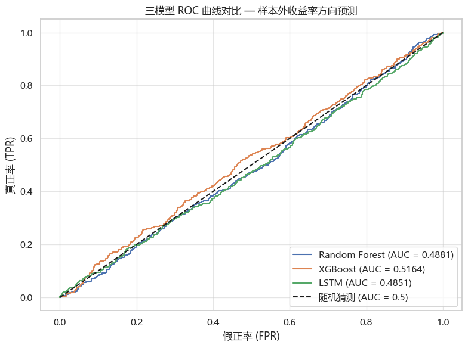

```python
plt.figure(figsize=(8, 6))

for key, name in model_names.items():
    y_prob = results_df[f"{key}_prob"].values
    fpr, tpr, _ = roc_curve(y_true, y_prob)
    auc_val = roc_auc_score(y_true, y_prob)
    plt.plot(fpr, tpr, label=f"{name} (AUC = {auc_val:.4f})")

plt.plot([0, 1], [0, 1], "k--", label="随机猜测 (AUC = 0.5)")
plt.xlabel("假正率 (FPR)")
plt.ylabel("真正率 (TPR)")
plt.title("三模型 ROC 曲线对比 — 样本外收益率方向预测")
plt.legend(loc="lower right")
plt.tight_layout()
plt.show()
```

### 7.4 混淆矩阵对比

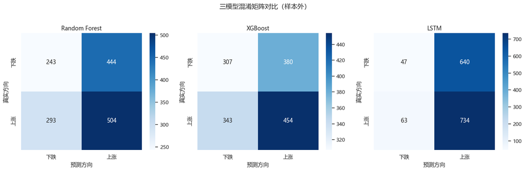

```python
fig, axes = plt.subplots(1, 3, figsize=(16, 5))

for ax, (key, name) in zip(axes, model_names.items()):
    y_pred = results_df[f"{key}_pred"].values
    cm = confusion_matrix(y_true, y_pred)
    sns.heatmap(cm, annot=True, fmt="d", cmap="Blues", ax=ax,
                xticklabels=["下跌", "上涨"], yticklabels=["下跌", "上涨"])
    ax.set_title(name)
    ax.set_xlabel("预测方向")
    ax.set_ylabel("真实方向")

plt.suptitle("三模型混淆矩阵对比（样本外）", fontsize=14, y=1.02)
plt.tight_layout()
plt.show()
```

## 8. 模型分析与可视化

### 8.1 滚动方向准确率变化

模型的预测能力可能随市场状态变化而波动。我们计算 60 日滚动方向准确率，观察模型在不同时期的表现：

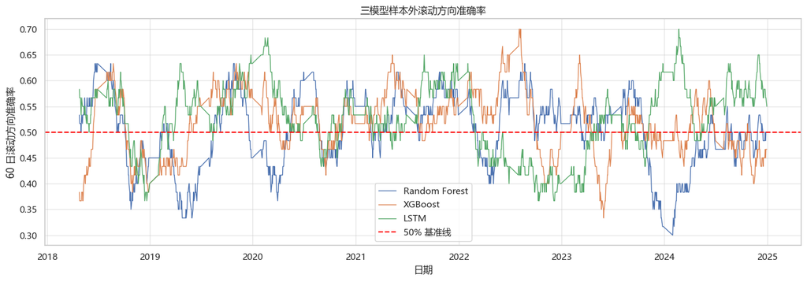

```python
fig, ax = plt.subplots(figsize=(14, 5))

for key, name in model_names.items():
    rolling_acc = (
        (results_df[f"{key}_pred"] == results_df["y_true"])
        .rolling(60).mean()
    )
    ax.plot(results_df.index, rolling_acc, label=name, linewidth=1)

ax.axhline(y=0.5, color="red", linestyle="--", label="50% 基准线")
ax.set_xlabel("日期")
ax.set_ylabel("60 日滚动方向准确率")
ax.set_title("三模型样本外滚动方向准确率")
ax.legend()
plt.tight_layout()
plt.show()
```

> **解读**：如果某个模型在某些市场阶段（如趋势市）表现明显优于随机猜测，但在另一些阶段（如震荡市）表现不佳，说明模型对市场状态的适应性有限。

### 8.2 特征重要性分析

使用最后一个滚动窗口训练的 Random Forest 和 XGBoost 模型来分析特征重要性：

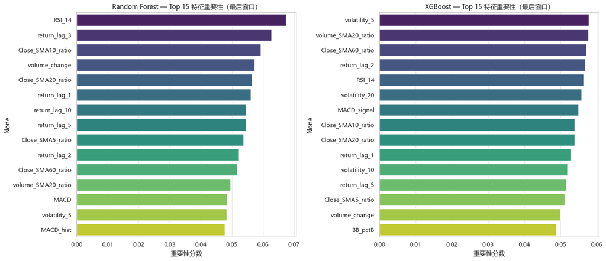

```python
fig, axes = plt.subplots(1, 2, figsize=(16, 7))

for ax, model, name in [
    (axes[0], rf, "Random Forest"),
    (axes[1], xgb_clf, "XGBoost"),
]:
    importance = pd.Series(model.feature_importances_, index=feature_cols)
    top15 = importance.sort_values(ascending=False).head(15)
    sns.barplot(x=top15.values, y=top15.index, ax=ax, palette="viridis")
    ax.set_title(f"{name} — Top 15 特征重要性（最后窗口）")
    ax.set_xlabel("重要性分数")

plt.tight_layout()
plt.show()
```

### 8.3 模拟累积收益

方向预测最终服务于交易。我们做一个简单的回测：如果模型预测上涨则持有，预测下跌则空仓，计算累积收益：

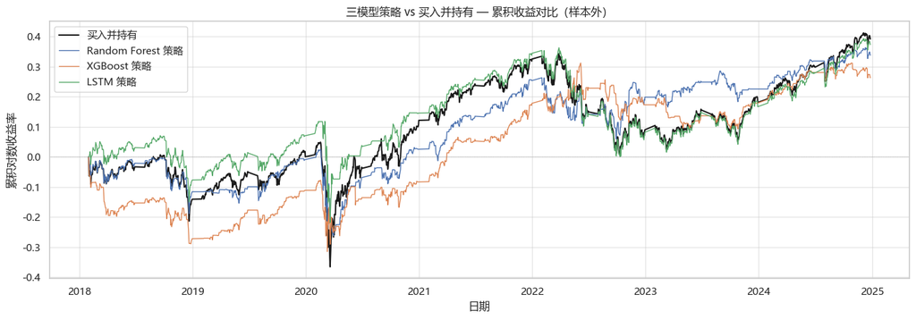

```python
# 获取对应日期的实际收益率
results_df["actual_return"] = df.loc[results_df.index, "log_return"].shift(-1)
results_df = results_df.dropna(subset=["actual_return"])
y_true = results_df["y_true"].values

fig, ax = plt.subplots(figsize=(14, 5))

# 基准：买入并持有
cum_baseline = results_df["actual_return"].cumsum()
ax.plot(results_df.index, cum_baseline, "k-", label="买入并持有", linewidth=1.5)

for key, name in model_names.items():
    # 模型策略：预测上涨时持有，否则空仓
    strategy_return = results_df["actual_return"] * results_df[f"{key}_pred"]
    cum_strategy = strategy_return.cumsum()
    ax.plot(results_df.index, cum_strategy, label=f"{name} 策略", linewidth=1)

ax.set_xlabel("日期")
ax.set_ylabel("累积对数收益率")
ax.set_title("三模型策略 vs 买入并持有 — 累积收益对比（样本外）")
ax.legend()
ax.axhline(y=0, color="gray", linestyle=":", linewidth=0.5)
plt.tight_layout()
plt.show()
```

> **重要声明**：上述回测是简化版本，未考虑交易成本、滑点、资金管理等因素。实际交易中这些因素会显著影响策略盈亏。此处仅用于比较模型的方向预测能力。

### 8.4 各模型按年度的方向准确率

```python
results_df["year"] = results_df.index.year

yearly_acc = []
for year in sorted(results_df["year"].unique()):
    mask = results_df["year"] == year
    row = {"年度": year}
    for key, name in model_names.items():
        acc = accuracy_score(
            results_df.loc[mask, "y_true"],
            results_df.loc[mask, f"{key}_pred"],
        )
        row[name] = round(acc, 4)
    yearly_acc.append(row)

yearly_df = pd.DataFrame(yearly_acc)
print("=== 各模型按年度方向准确率 ===")
display(yearly_df)
```

```
=== 各模型按年度方向准确率 ===
```

|  | 年度 | Random Forest | XGBoost | LSTM |
| --- | --- | --- | --- | --- |
| 0 | 2018 | 0.5118 | 0.4597 | 0.5166 |
| 1 | 2019 | 0.4648 | 0.5446 | 0.5775 |
| 2 | 2020 | 0.5140 | 0.5047 | 0.5234 |
| 3 | 2021 | 0.5493 | 0.5681 | 0.5587 |
| 4 | 2022 | 0.5142 | 0.5330 | 0.4198 |
| 5 | 2023 | 0.4833 | 0.4833 | 0.5311 |
| 6 | 2024 | 0.4810 | 0.4905 | 0.5619 |

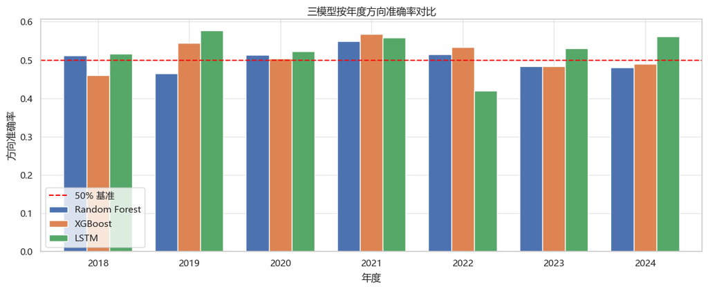

```python
yearly_df_plot = yearly_df.set_index("年度")
yearly_df_plot.plot(kind="bar", figsize=(12, 5), width=0.75)
plt.axhline(y=0.5, color="red", linestyle="--", label="50% 基准")
plt.ylabel("方向准确率")
plt.title("三模型按年度方向准确率对比")
plt.legend()
plt.xticks(rotation=0)
plt.tight_layout()
plt.show()
```

## 9. 模型综合对比

```python
summary = pd.DataFrame({
    "模型": ["Random Forest", "XGBoost", "LSTM"],
    "样本外 AUC": [
        round(roc_auc_score(y_true, results_df["rf_prob"]), 4),
        round(roc_auc_score(y_true, results_df["xgb_prob"]), 4),
        round(roc_auc_score(y_true, results_df["lstm_prob"]), 4),
    ],
})

display(summary)
```

|  | 模型 | 样本外 AUC |
| --- | --- | --- |
| 0 | Random Forest | 0.4871 |
| 1 | XGBoost | 0.5152 |
| 2 | LSTM | 0.4854 |

## 10. 实验结论

1. **永远不要只拟合收盘价**——看起来很美但毫无用处。
2. **时间序列预测必须用 Walk-Forward 评估**——随机划分会导致严重的信息泄露。
3. **样本外表现才是唯一标准**——样本内表现再好也可能只是过拟合。
4. **模型复杂度不等于预测能力**——LSTM 不一定优于树模型，尤其在噪声大的场景中。
5. **特征工程的重要性不亚于模型选择**——好的技术指标远比复杂的模型架构更有价值。

## 11. 课堂思考题

1. 如果把预测目标从"未来 1 日方向"改为"未来 5 日方向"，你预期预测难度会增加还是降低？为什么？
2. 本实验的 LSTM 使用了与树模型相同的技术指标作为输入。如果改为直接用原始 OHLCV 数据输入 LSTM，效果会更好吗？试分析原因。
3. 在滚动窗口中，训练集使用了全部历史数据（expanding window）。如果改为只使用最近 2 年的数据（fixed-size window），哪种方式可能更好？为什么？
4. 方向准确率 53% 在扣除交易成本后可能就不盈利了。试估算：如果单边交易成本为 0.1%，日频策略大约需要多少方向准确率才能保本？
5. 如何将多个模型的预测信号融合（Ensemble）？提出至少两种方法并分析优劣。